# Lecture 08 — Hough Transform

Lecture 8

Kaveh Fathian

Computer Science Department, Colorado School of Mines

## Learning Objectives

By the end of this lecture, you should be able to:

- Explain how image points vote in Hough space and how peaks identify line and circle models.
- Interpret the polar representation of a line and explain how gradient directions help locate circle centers.
- Use OpenCV to detect lines and circles, and explain how bin sizes, thresholds, and search ranges affect detection.

## What Is the Hough Transform?

**Hough Transform**

The Hough transform is a generic framework for detecting a parametric model by a voting process. In computer vision, Hough Transform is commonly used to detect lines, circles, and other parametric shapes in images from imperfect edge detections.

- A **parametric model** describes a shape using a small set of numbers.
  - A *line* can be described by its *slope* and *intercept*.
  - A *circle* can be described by its *center* and *radius*.
- Image points **vote** for models that could explain their locations.
- Models receiving strong support become detection candidates.

[figure not shown]

## From Edge Pixels to Lines

- **Canny** finds edge pixels at local intensity changes. It does **not** assign them to a shared line model.
- **Hough** groups supporting pixels into **line models**, **including pixels separated by gaps**.
- The yellow lines show four distinct candidates after excluding near-horizontal lines. Hough detects straight structures; it does not know which ones are lane boundaries.

[figure not shown]

## Gaps Do Not Necessarily Prevent Detection

[figure not shown]

- Separated fragments can support the same line even when part of it is hidden.
- The detected line extends through the gap; this is a model **prediction**, not an observed edge.
- Detection still requires enough supporting evidence. Heavy clutter or too little visible structure can prevent a reliable result.

## The Same Idea Can Detect Circles

A circle is a parametric model with center $(a,b)$ and radius $r$:

$$(x-a)^2 + (y-b)^2 = r^2$$

[figure not shown]

- Boundary evidence supports candidate circle centers and radii.

## Representing a Line with Two Numbers

A line can be written as

$$y = mx + b,$$

where $m$ is its **slope** and $b$ is its **$y$-intercept**.

[figure not shown]

- Lines A and B have the same slope but different intercepts.
- Lines B and C have the same intercepts but different slopes.

## A Line Becomes a Point

[figure not shown]

- In **image space**, a line has the equation $y = mx + b$.
- In **parameter space**, a **point** specifies an entire line $(m,b)$.
- Parallel lines share the same $m$ coordinate but have different $b$ coordinates.
- Lines with the same intercept share the same $b$ coordinate but can have different $m$ coordinates.

## Estimating a Line from an Edge Point

Given a point $(x,y)$ on an image edge that we want to estimate its line parameters:

- The image gradient $(I_x,I_y)$ is perpendicular to the edge.
- We can estimate its line parameters as:
  $$m=-\frac{I_x}{I_y},
  \qquad
  b=y-mx.$$

[figure not shown]

Each edge point now supplies an estimated line $(m,b)$ that we can count.

Note that near-vertical edges have $I_y \approx 0$ and require a different representation, which we will address later.

## Binning the Line Parameters

The parameters $m$ and $b$ are continuous. Divide their ranges into a grid of **bins**.

**Voting in the Hough Space**

1. Initialize every bin to zero.
2. Estimate $(m,b)$ at an edge point.
3. Add one to the bin containing that estimate.
4. Repeat for the other edge points.
- Nearby estimates can fall into the same bin.
- A bin’s value counts points that support a line model, not the number of separate physical lines.

[figure not shown]

Each bin spans $\Delta m=0.2$ and $\Delta b=100$ pixels in this example.

## One Edge Point, One Vote

[figure not shown]

- The marked point and its gradient give one estimated line.
- That estimate falls into one parameter-space bin.
- We increment that bin by **one**.

## More Points Add Votes

[figure not shown]

- Points along the same straight edge tend to produce similar slopes and intercepts.
- Their votes accumulate in the same bin or nearby bins.
- Noise, corners, and other edges spread votes across additional bins.
- **A large count indicates strong support for a line with that bin’s parameters.**

## Peaks Identify Line Candidates

[figure not shown]

- Strong, separated peaks identify candidate lines supported by many edge points.
- Nearby bins may describe the same line, so we can suppress neighboring peaks.
- A high bin count measures support; it does not guarantee a correct detection.

## Do We Need a Slope at Every Edge Point?

So far, each point must provide a unique line estimate:

$$m=-\frac{I_x}{I_y},
\qquad
b=y-mx.$$

- This requires a reliable gradient estimate.
- Noise and corners can make direction uncertain.

[figure not shown]

**Can the point vote without first choosing one slope and intercept?**

- Hough’s key idea: Instead of choosing one line from the gradient, let the point vote for **all lines that could pass through it**.

## Which Lines Pass Through One Point?

For image point $p = (2,3)$, any line through it must satisfy

$$3=2m+b
\qquad\Longrightarrow\qquad
b=3-2m.$$

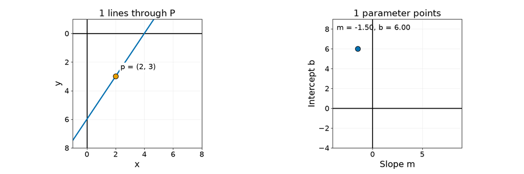

- Choosing a slope $m$, gives an intercept $b$.
- Each possible image line contributes one parameter point. As we add more possibilities, those parameter points trace a **line in Hough space**.

## Image Point Becomes a Hough Line

For a fixed image point $(x_0,y_0)$,

$$y_0=mx_0+b
\qquad\Longrightarrow\qquad
\boxed{b=-x_0m+y_0.}$$

[figure not shown]

- In image space, $x_0$ and $y_0$ are fixed: we have one point.
- In Hough space, $m$ and $b$ vary: we have all possible lines through that point.
- The Hough-space line has slope $-x_0$ and intercept $y_0$.

## Collinear Points Share an Intersection

Add points from the image line $y=0.5x+2$. Each point contributes its own Hough-space line.

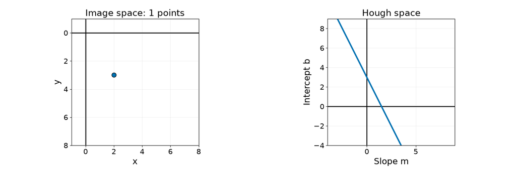

- Every blue Hough-space line passes through $(m,b)=(0.5,2)$.
- That shared intersection identifies the line containing all seven image points.
- Each additional collinear point adds support at the same parameters.

## A Point Outside the Line

Now add $q=(0,7)$, which does not lie on $y=0.5x+2$. Its Hough-space line is $b=7$.

[figure not shown]

- The orange Hough-space line does not pass through the blue intersection.
- At $m=0.5$, it gives $b=7$, rather than $b=2$.
- It crosses individual blue lines elsewhere, but those pairwise intersections have less support.

## Another Group Produces Another Intersection

Add more points collinear with $q$, along $y=5x+7$.

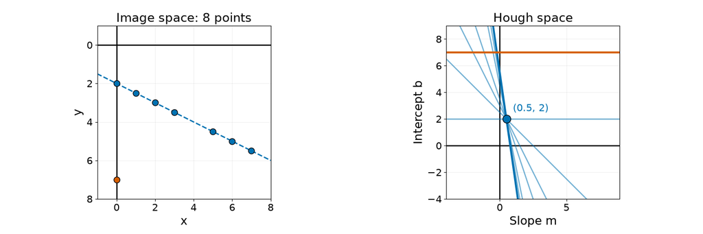

- The blue group supports $(m,b)=(0.5,2)$.
- The orange group supports $(m,b)=(5,7)$.
- Multiple image lines produce multiple locations where many Hough-space lines intersect.
- The colors distinguish the known groups in this example. In an image, we must discover the groups from their votes.

## Voting Without Edge Directions

Each edge point $(x,y)$ votes along its entire Hough-space line:

$$b=y-mx.$$

**Hough Voting for Lines**

1. Create a grid of slope and intercept bins.
2. For each edge point $(x,y)$:
   - Try each sampled slope $m$.
   - Compute $b=y-mx$.
   - Increment the corresponding $(m,b)$ bin.
3. Find strong, separated peaks.
4. Map each peak back to an image line $y=mx+b$.
- Each point votes for many possible models.
- Collinear points reinforce the same parameters.
- Binning allows nearby intersections to accumulate together when image measurements are imperfect.

## Detecting the Museum Lines Without Edge Directions

[figure not shown]

- Many Hough-space lines overlap near each detected peak.
- The peaks recover the two main building edges.
- Voting uses edge locations only; it does not use their gradient directions.

## What Happens to a Vertical Line?

The highlighted, nearly vertical building edge is modeled as $x=c$.

**What is its slope?**

- An exactly vertical line has an undefined slope.
- No finite pair $(m,b)$ represents it as $y=mx+b$.

**How large must Hough space be?**

For lines through $(x_0,y_0)$,

$$b=y_0-m x_0.$$

When $x_0>0$,

$$m\rightarrow+\infty
\quad\Longrightarrow\quad
b\rightarrow-\infty.$$

[figure not shown]

**How can we represent all line orientations without unbounded slopes and intercepts?**

## Representing a Line with Distance and Angle

Instead of slope and intercept $(m,b)$, describe a line using $(r,\theta)$:

- $\theta$ is the angle of the line’s **normal**, measured from the positive $x$ axis in the range $0\leq\theta<180^\circ$.
- $r$ is the **signed perpendicular distance** from the origin. The geometric distance is $|r|$.

Given image gradient $(I_x, I_y)$ or line equation $y = mx + b$:

1. $\theta = \operatorname{atan2}(I_y, I_x) \bmod \pi$, or $\theta = \operatorname{atan2}(1,-m)$.
2. $r = x\cos\theta+y\sin\theta$ for any point $(x,y)$ on the line, or $r = \frac{b}{\sqrt{m^2+1}}$.
- If $r>0$, the closest point on the line lies along the chosen normal from the origin.
- If $r<0$, it lies in the opposite direction.

[figure not shown]

We keep image coordinates: $x$ points right and $y$ points down, so positive $\theta$ appears clockwise.

## Binning the Polar Parameters

- Divide Hough space into angle and distance bins.
- Use $0\leq\theta<180^\circ$, and $-D\leq r\leq D$.
- For a $W\times H$ image, $D=\sqrt{(W-1)^2+(H-1)^2}$.
- A vertical line $x=c$ has $\theta=0^\circ$ and $r=c$.
- A horizontal line $y=c$ has $\theta=90^\circ$ and $r=c$.
- All orientations now have finite parameters.

[figure not shown]

**Polar Hough Voting**

1. For each edge point $(x,y)$, try each sampled angle $\theta$.
2. Compute $r=x\cos\theta+y\sin\theta$ and increment the corresponding bin.
3. Find strong peaks to identify supported line models.

## A Point Becomes a Sinusoid

For the same image point $p=(2,3)$, the possible line parameters satisfy

$$r(\theta)=2\cos\theta+3\sin\theta.$$

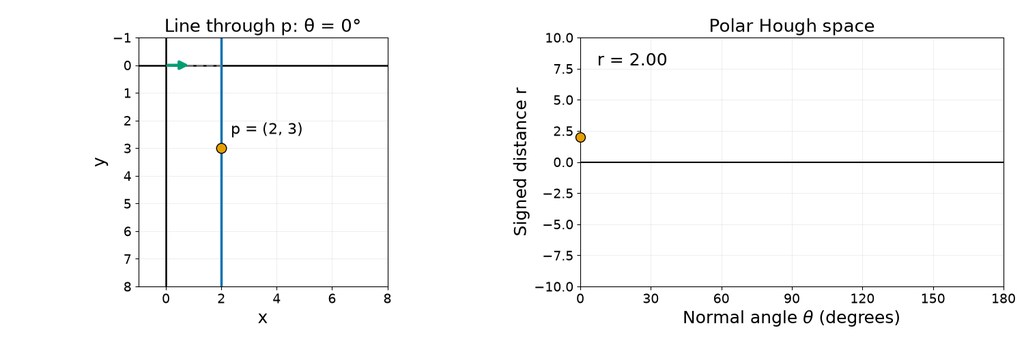

- Rotating the normal selects different lines through the same image point.
- Each candidate line gives one point in Hough space. Together, these points trace a sinusoid.
- The green arrow shows the normal direction. The dashed segment connects the origin to the closest point on the line.

## Collinear Points Share a Polar Intersection

Use the same image points on $y=0.5x+2$. Each point now contributes a sinusoid.

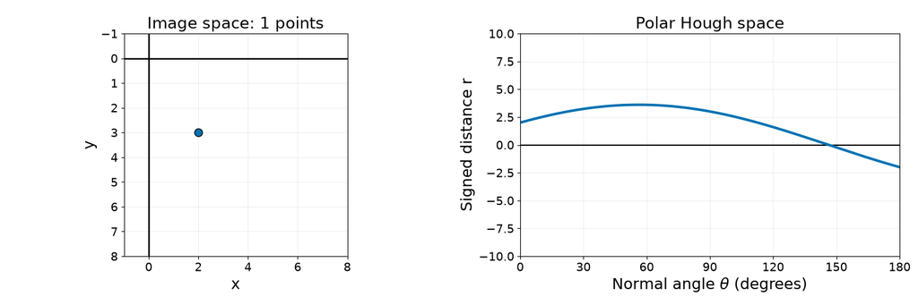

- All seven curves pass through the same parameters: $\theta\approx116.6^\circ$, $r\approx1.79$.
- These parameters describe the original image line.
- Additional collinear points reinforce the same Hough-space location.

## What Changes When Points Are Noisy?

Add small position errors to points sampled from the same line $y=0.5x+2$.

[figure not shown]

- The points no longer lie exactly on one line.
- Their sinusoids no longer share one exact intersection.
- Support spreads across a neighborhood in Hough space, so we look for a concentration of votes.

## Bin Size and Noisy Votes

Use the same noisy points with two different accumulator grids.

[figure not shown]

- Fine bins provide precise parameter locations, but noise can split support across many bins.
- Coarser bins collect more nearby votes, but reduce precision and can merge distinct lines.
- Lightly smoothing the accumulator can combine neighboring support before finding peaks.
- For multiple lines, suppress nearby peaks. To recover line segments, examine the supporting image points and their gaps.

## Hough Line Detection in OpenCV

```python
field_gray = cv2.cvtColor(field_rgb, cv2.COLOR_RGB2GRAY)

field_polygon = np.array([[310, 28], [1220, 120],
    [1190, 400], [40, 160]], dtype=np.int32)
field_mask = np.zeros_like(field_gray)
cv2.fillPoly(field_mask, [field_polygon], 255)

field_smooth = cv2.GaussianBlur(field_gray, (5, 5), 1.2)

field_edges = cv2.Canny(field_smooth, 40, 100)

field_edges = cv2.bitwise_and(field_edges, field_mask)
```

- Gaussian smoothing reduces noise & small intensity variations.
- Canny uses thresholds of **100** for strong edges and **40** to continue connected weaker edges.
- We apply a mask after Canny to search only for lines inside the field.

[figure not shown]

## Hough Line Detection in OpenCV

```python
field_lines = cv2.HoughLines(
    field_edges,
    rho=1,
    theta=np.deg2rad(1),
    threshold=140,
    min_theta=0,
    max_theta=np.deg2rad(80)
)
```

Each returned $(r,\theta)$ defines a line: $x\cos\theta+y\sin\theta=r$.

- `rho=1`: distance bins spaced **1 pixel** apart.
- `theta`: angle bins spaced **1°** apart, supplied in radians.
- `threshold=140`: a peak must exceed **140 votes**. Lower values admit weaker lines and more false detections.
- `min_theta`, `max_theta`: search **normal angles** from **0° to 80°**, targeting the yard lines in this image.

[figure not shown]

## Circle Detection

A circle has center $(a,b)$ and radius $r$:

$$(x-a)^2+(y-b)^2=r^2.$$

If $r$ is known, an edge point $(x,y)$ votes for all centers $(a,b)$ at distance $r$ from it.

[figure not shown]

- Each colored point produces a circle of possible centers in the $(a,b)$ parameter space.
- Points on the same image circle support a shared center. Binning these votes produces a peak.

## Searching for the Radius

When the radius is unknown, the full parameter space is **three-dimensional**: $(a,b,r)$.

- A direct approach repeats center voting for each tested radius.
- Gradient directions reduce the search: a circle’s normal passes through its center.

For a unit gradient direction $\hat{\mathbf{g}}$ at an edge point,

$$\begin{bmatrix}a\\b\end{bmatrix}
=
\begin{bmatrix}x\\y\end{bmatrix}
\pm r\hat{\mathbf{g}}.$$

**Gradient-Based Radii Search**

1. Find edges and their gradient directions.
2. Vote for centers along those directions.
3. Estimate radii supported by edges around each candidate center.

[figure not shown]

Ideal circle normals are shown here. Measured gradients are noisy, so nearby votes must be combined.

## Hough Circle Detection in OpenCV

```python
coins_smooth = cv2.GaussianBlur(coins_gray, (7, 7), 1.5)

# For visualization only:
coins_edges = cv2.Canny(coins_smooth, 60, 120)
```

- Smoothing reduces noise & fine textures while preserving the coin outlines.
- Canny also detects lettering and background edges.
- We pass the **smoothed grayscale** image to `HoughCircles` to computes edges and gradients (internally).
- `Canny` is for visualization only; `HoughCircles` computes edges internally.

[figure not shown]

## Hough Circle Detection in OpenCV

```python
coin_circles = cv2.HoughCircles(
    coins_smooth,
    cv2.HOUGH_GRADIENT,
    dp=1.2,
    minDist=170,
    param1=120,
    param2=45,
    minRadius=85,
    maxRadius=115
)
```

- `dp=1.2`: center-accumulator cells span approximately **1.2 image pixels**.
- `minDist=170`: minimum separation between detected centers; reduces duplicate detections.
- `param1=120`: upper **internal Canny threshold**; the lower threshold is set to half of this value as **60**.
- `param2=45`: voting threshold for accepting circle candidates. Lower values admit weaker candidates and more false detections.
- `minRadius`, `maxRadius`: search radii from **85 to 115 pixels** in the image.

Each result contains $(a,b,r)$: center coordinates and radius.

[figure not shown]

## Key Takeaways

- The Hough transform works through voting in parameter space. Separated edge points can support the same model despite gaps or partial occlusion.
- Polar line parameters $(r,\theta)$ handle all line orientations. Collinear image points produce sinusoids that meet at the line’s parameters.
- Circles are described by their center and radius $(a,b,r)$. Gradient directions constrain candidate centers and reduce the search.

**Detection Depends on the Search Parameters**

Noise spreads votes across nearby bins. Bin sizes, thresholds, and parameter ranges affect which models are detected and whether nearby models remain distinguishable.